# Reproducible Research: Peer Assessment 1

Loading and preprocessing the data

```r
setwd("C:/Users/Next Step/Documents")
activity=read.csv("activity.csv")
library(dplyr)
```

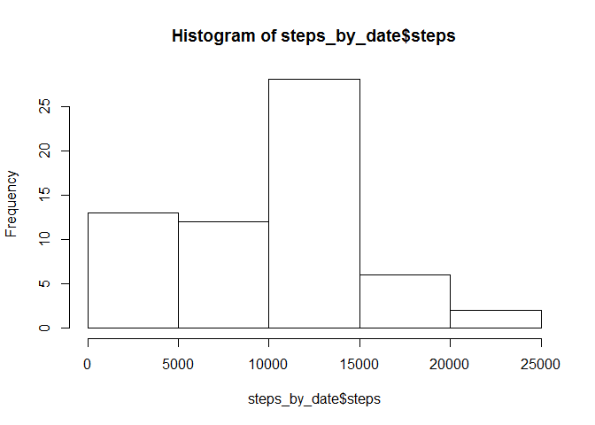

```r
gp_by_date=group_by(activity,date)
steps_by_date=summarize(gp_by_date,steps=sum(steps,na.rm=TRUE))
hist(steps_by_date$steps)
```

What is mean total number of steps taken per day?

```r
mean_steps=mean(steps_by_date$steps)
median_steps=median(steps_by_date$steps)
```

The mean total number of steps taken is 9354.2295082.  
The median total number of steps taken is 10395.

What is the average daily activity pattern?

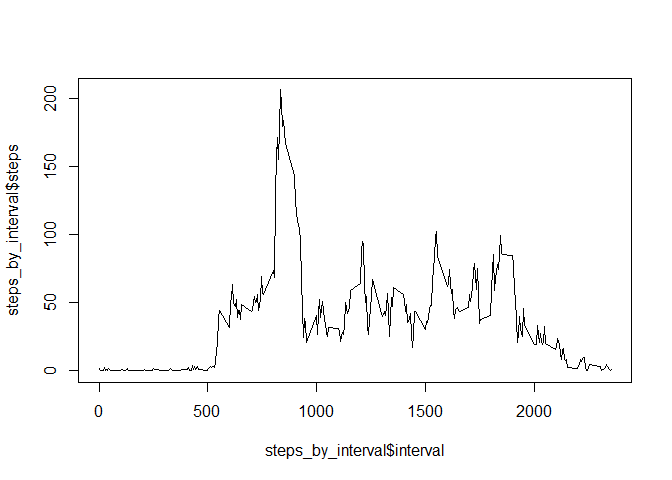

```r
gp_by_interval=group_by(activity,interval)
steps_by_interval=summarize(
        gp_by_interval,steps=mean(steps,na.rm=TRUE)
        )
plot(steps_by_interval$interval,steps_by_interval$steps,"l")
```

```r
max_val=max(steps_by_interval$steps)
max_interval=steps_by_interval$interval[steps_by_interval$steps==max_val]
num_of_nas=sum(is.na(activity$steps))
```

The 5 minute interval that has the largest average number of steps taken is 835.

Inputing missing values: have been replaced with the mean for that interval across all dates.

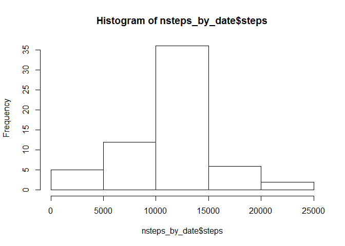

```r
new_activity=activity
len=length(activity$steps)
for (i in 1:len) {
        if(is.na(activity$steps[i])){
                new_activity[i,1]=steps_by_interval[(i-1)%%288+1,2]
                }
}
ngp_by_date=group_by(new_activity,date)
nsteps_by_date=summarize(ngp_by_date,steps=sum(steps,na.rm=TRUE))
hist(nsteps_by_date$steps)
```

```r
nmean_steps=mean(nsteps_by_date$steps)
nmedian_steps=median(nsteps_by_date$steps)
```

Are there differences in activity patterns between weekdays and weekends?

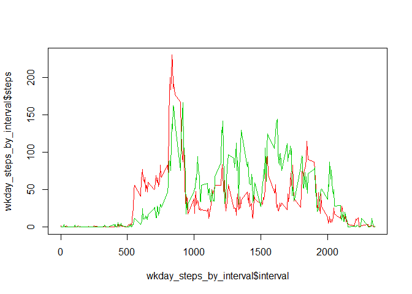

```r
my_weekday=function(date) if(as.POSIXlt(date)$wday<6&as.POSIXlt(date)$wday>0){
        "weekday"} else "weekend"
kind.of.day=lapply(activity$date, my_weekday)
new_activity$kind.of.day=kind.of.day
new_activity_wkday=new_activity[new_activity$kind.of.day=="weekday",1:3]
new_activity_wkend=new_activity[new_activity$kind.of.day=="weekend",1:3]
wkday_gp_by_interval=group_by(new_activity_wkday,interval)
wkday_steps_by_interval=summarize(
        wkday_gp_by_interval,steps=mean(steps,na.rm=TRUE)
        )
wkend_gp_by_interval=group_by(new_activity_wkend,interval)
wkend_steps_by_interval=summarize(
        wkend_gp_by_interval,steps=mean(steps,na.rm=TRUE)
        )
plot(wkday_steps_by_interval$interval,wkday_steps_by_interval$steps,"l",col=2)
lines(wkend_steps_by_interval$interval,wkend_steps_by_interval$steps,"l",col=3)
```

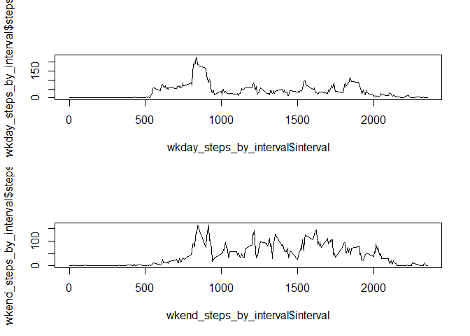

```r
par(mfrow=c(2,1))
plot(wkday_steps_by_interval$interval,wkday_steps_by_interval$steps,"l")
plot(wkend_steps_by_interval$interval,wkend_steps_by_interval$steps,"l")
```

As can be seen from the plots (in the first one, the red is weekday and the green is weekend), except for an inital burst of activity at the beginning of the day during weekdays, activity is typically at a higher level for most of the day.